# Time Series Analysis 2

```r
getwd()
```

```
## [1] "C:/Users/Sinan/Desktop"
```

```r
setwd("C:/Users/Sinan/Desktop")
salesdata<-read.table("salesdata.txt",header = TRUE)
salesperson<-read.table("salesperson.txt",header = TRUE)

library(corrplot)
library(car)
library(gvlma)
```

```r
head(salesperson,n=10)
```

```
##    SALES APT  AGE ANX EXP GPA
## 1     44  10 22.1 4.9   0 2.4
## 2     47  19 22.5 3.0   1 2.6
## 3     60  27 23.1 1.5   0 2.8
## 4     71  31 24.0 0.6   3 2.7
## 5     61  64 22.6 1.8   2 2.0
## 6     60  81 21.7 3.3   1 2.5
## 7     58  42 23.8 3.2   0 2.5
## 8     56  67 22.0 2.1   0 2.3
## 9     66  48 22.4 6.0   1 2.8
## 10    61  64 22.6 1.8   1 3.4
```

```r
cor(salesperson)
```

```
##            SALES        APT        AGE        ANX        EXP        GPA
## SALES  1.0000000  0.6761204  0.7981406 -0.2958598  0.5498340  0.6217841
## APT    0.6761204  1.0000000  0.2277062 -0.2219880  0.3496392  0.3177716
## AGE    0.7981406  0.2277062  1.0000000 -0.2867937  0.5395681  0.6945689
## ANX   -0.2958598 -0.2219880 -0.2867937  1.0000000 -0.2786892 -0.2443816
## EXP    0.5498340  0.3496392  0.5395681 -0.2786892  1.0000000  0.3121288
## GPA    0.6217841  0.3177716  0.6945689 -0.2443816  0.3121288  1.0000000
```

#### Because of correlations of all values with SALES, AGE and APT variables can be used to predict SALES values.

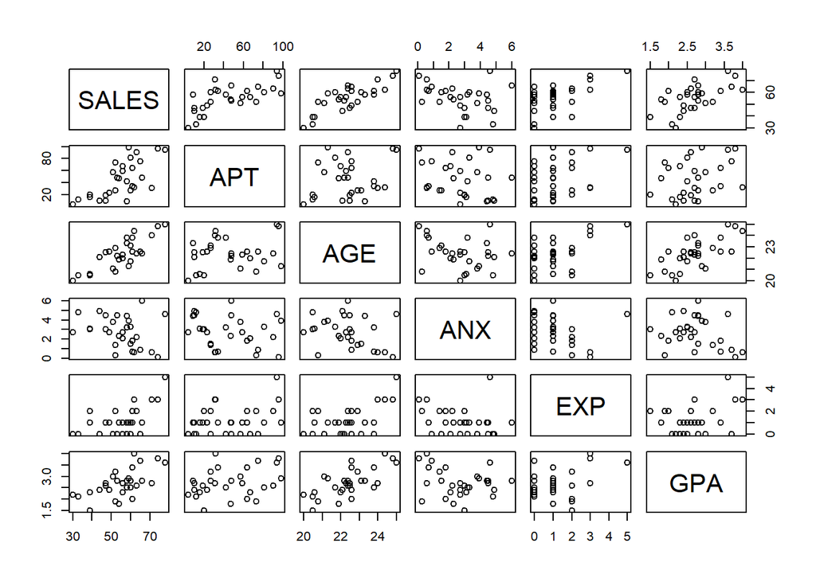

```r
pairs(salesperson)
```

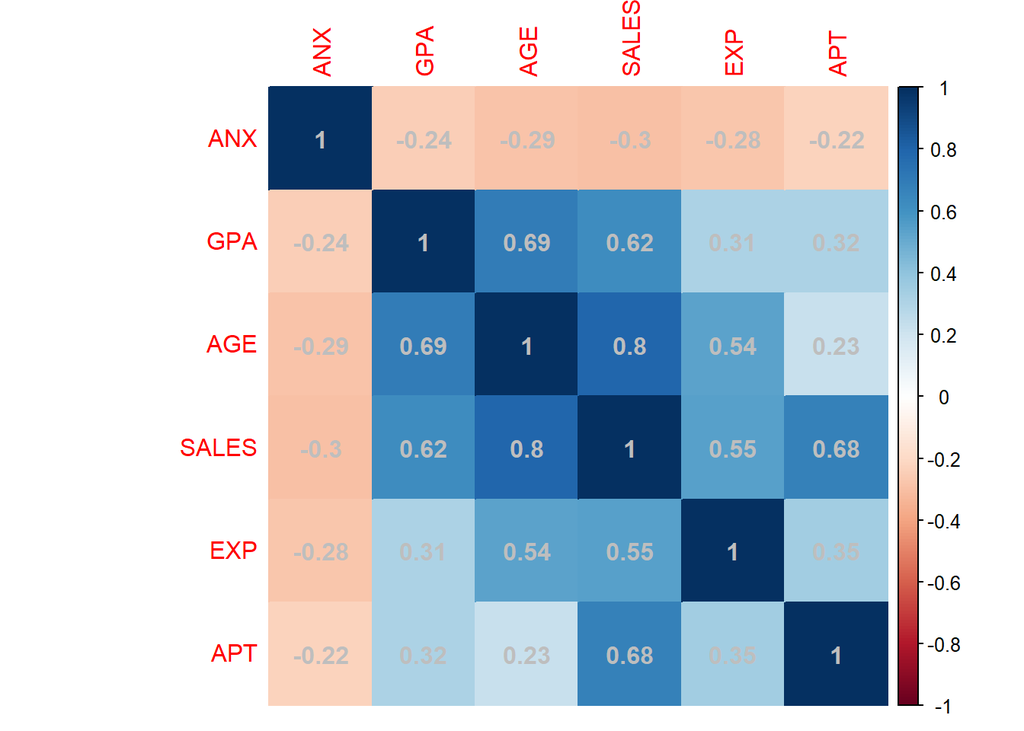

```r
corrplot(cor(salesperson),order = "AOE",method = "color",addCoef.col = "gray" )
```

#### Implemented stepwise regression by following the steps below and obtain a final regression model.

```r
reg1<-lm(SALES~AGE,data =salesperson)
summary(reg1)
```

```
##
## Call:
## lm(formula = SALES ~ AGE, data = salesperson)
##
## Residuals:
##     Min      1Q  Median      3Q     Max
## -9.1399 -6.9177  0.6793  4.6449 11.4345
##
## Coefficients:
##             Estimate Std. Error t value Pr(>|t|)
## (Intercept) -100.853     22.311   -4.52 0.000103 ***
## AGE            6.968      0.994    7.01 1.27e-07 ***
## ---
## Signif. codes:  0 '***' 0.001 '**' 0.01 '*' 0.05 '.' 0.1 ' ' 1
##
## Residual standard error: 6.847 on 28 degrees of freedom
## Multiple R-squared:  0.637,  Adjusted R-squared:  0.6241
## F-statistic: 49.14 on 1 and 28 DF,  p-value: 1.267e-07
```

#### Choosed the variable having the highest absolute correlation value. Constructed an initial simple linear regression model using this variable and the response.

```r
summary.aov(lm(SALES~AGE+APT,data =salesperson))
```

```
##             Df Sum Sq Mean Sq F value   Pr(>F)
## AGE          1 2303.7  2303.7  163.50 5.72e-13 ***
## APT          1  932.2   932.2   66.16 9.76e-09 ***
## Residuals   27  380.4    14.1
## ---
## Signif. codes:  0 '***' 0.001 '**' 0.01 '*' 0.05 '.' 0.1 ' ' 1
```

```r
summary.aov(lm(SALES~AGE+ANX,data =salesperson))
```

```
##             Df Sum Sq Mean Sq F value  Pr(>F)
## AGE          1 2303.7  2303.7  48.032 1.9e-07 ***
## ANX          1   17.7    17.7   0.368   0.549
## Residuals   27 1294.9    48.0
## ---
## Signif. codes:  0 '***' 0.001 '**' 0.01 '*' 0.05 '.' 0.1 ' ' 1
```

```r
summary.aov(lm(SALES~AGE+EXP,data =salesperson))
```

```
##             Df Sum Sq Mean Sq F value   Pr(>F)
## AGE          1 2303.7  2303.7  50.155 1.29e-07 ***
## EXP          1   72.5    72.5   1.578     0.22
## Residuals   27 1240.1    45.9
## ---
## Signif. codes:  0 '***' 0.001 '**' 0.01 '*' 0.05 '.' 0.1 ' ' 1
```

```r
summary.aov(lm(SALES~AGE+GPA,data =salesperson))
```

```
##             Df Sum Sq Mean Sq F value   Pr(>F)
## AGE          1 2303.7  2303.7  48.561 1.72e-07 ***
## GPA          1   31.8    31.8   0.669     0.42
## Residuals   27 1280.9    47.4
## ---
## Signif. codes:  0 '***' 0.001 '**' 0.01 '*' 0.05 '.' 0.1 ' ' 1
```

#### Out of the variables that are not in the model, built a new model by adding one variable into the current model. Used the command anova(currentmodel,newmodel) to test the significance of this new variable with an F-test. Made this for all variables which are not in the current model. Choosed the variable that corresponds to largest F-statistic (smallest p-value) and update our current model by adding this variable.

```r
currentmodel<-lm(SALES~AGE+APT,data =salesperson)
reducedmodel<-lm(SALES~APT,data =salesperson)
summary.aov(currentmodel)
```

```
##             Df Sum Sq Mean Sq F value   Pr(>F)
## AGE          1 2303.7  2303.7  163.50 5.72e-13 ***
## APT          1  932.2   932.2   66.16 9.76e-09 ***
## Residuals   27  380.4    14.1
## ---
## Signif. codes:  0 '***' 0.001 '**' 0.01 '*' 0.05 '.' 0.1 ' ' 1
```

```r
summary.aov(reducedmodel)
```

```
##             Df Sum Sq Mean Sq F value   Pr(>F)
## APT          1   1653  1653.2   23.58 4.11e-05 ***
## Residuals   28   1963    70.1
## ---
## Signif. codes:  0 '***' 0.001 '**' 0.01 '*' 0.05 '.' 0.1 ' ' 1
```

#### Once a new variable is added into our current model, built a reduced model by removing one of the variables which was already in our current model (except the last one added in the previous step). Use the command anova(currentmodel,reducedmodel) to test the significance of the removed variable with an F-test. If the p-value of this test is larger than a sensible significance level (if F-statistic is small then critical F-value), then updated our current equation by removing this variable. Otherwise, did not touch that variable. Made this for all variables in our current model, except the last variable added in the second step.

```r
summary.aov(lm(SALES~AGE+APT+ANX,data =salesperson))
```

```
##             Df Sum Sq Mean Sq F value   Pr(>F)
## AGE          1 2303.7  2303.7  157.81 1.51e-12 ***
## APT          1  932.2   932.2   63.86 1.81e-08 ***
## ANX          1    0.9     0.9    0.06    0.808
## Residuals   26  379.5    14.6
## ---
## Signif. codes:  0 '***' 0.001 '**' 0.01 '*' 0.05 '.' 0.1 ' ' 1
```

```r
summary.aov(lm(SALES~AGE+APT+GPA,data =salesperson))
```

```
##             Df Sum Sq Mean Sq F value   Pr(>F)
## AGE          1 2303.7  2303.7 158.213 1.47e-12 ***
## APT          1  932.2   932.2  64.021 1.76e-08 ***
## GPA          1    1.8     1.8   0.126    0.725
## Residuals   26  378.6    14.6
## ---
## Signif. codes:  0 '***' 0.001 '**' 0.01 '*' 0.05 '.' 0.1 ' ' 1
```

```r
summary.aov(lm(SALES~AGE+APT+EXP,data =salesperson))
```

```
##             Df Sum Sq Mean Sq F value   Pr(>F)
## AGE          1 2303.7  2303.7  157.45 1.55e-12 ***
## APT          1  932.2   932.2   63.71 1.85e-08 ***
## EXP          1    0.0     0.0    0.00    0.986
## Residuals   26  380.4    14.6
## ---
## Signif. codes:  0 '***' 0.001 '**' 0.01 '*' 0.05 '.' 0.1 ' ' 1
```

#### Checking the correctness of the result can also be done by using step function in R.

```r
Fitall<-lm(SALES~.,data = salesperson)
Fitstart<-lm(SALES~AGE,data = salesperson)
step(Fitstart,direction = "forward",scope = formula(Fitall))
```

```
## Start:  AIC=117.36
## SALES ~ AGE
##
##        Df Sum of Sq     RSS     AIC
## + APT   1    932.20  380.42  82.202
## <none>              1312.61 117.357
## + EXP   1     72.46 1240.15 117.654
## + GPA   1     31.76 1280.85 118.623
## + ANX   1     17.67 1294.95 118.951
##
## Step:  AIC=82.2
## SALES ~ AGE + APT
##
##        Df Sum of Sq    RSS    AIC
## <none>              380.42 82.202
## + GPA   1   1.84081 378.58 84.057
## + ANX   1   0.88082 379.54 84.133
## + EXP   1   0.00487 380.41 84.202
```

```
##
## Call:
## lm(formula = SALES ~ AGE + APT, data = salesperson)
##
## Coefficients:
## (Intercept)          AGE          APT
##    -86.7915       5.9314       0.1997
```

```r
reglast<-lm(SALES~AGE+APT,data =salesperson)
summary(reglast)
```

```
##
## Call:
## lm(formula = SALES ~ AGE + APT, data = salesperson)
##
## Residuals:
##     Min      1Q  Median      3Q     Max
## -5.4829 -2.3181 -0.6084  1.1793 10.3399
##
## Coefficients:
##              Estimate Std. Error t value Pr(>|t|)
## (Intercept) -86.79154   12.35276  -7.026 1.49e-07 ***
## AGE           5.93145    0.55964  10.599 4.02e-11 ***
## APT           0.19973    0.02456   8.134 9.76e-09 ***
## ---
## Signif. codes:  0 '***' 0.001 '**' 0.01 '*' 0.05 '.' 0.1 ' ' 1
##
## Residual standard error: 3.754 on 27 degrees of freedom
## Multiple R-squared:  0.8948, Adjusted R-squared:  0.887
## F-statistic: 114.8 on 2 and 27 DF,  p-value: 6.266e-14
```

```r
head(salesdata,n=10)
```

```
##      PROFIT    SALES
## 1  18.51422 30.12393
## 2  20.83479 36.94505
## 3  16.09410 20.20793
## 4  20.64832 34.47554
## 5  17.03614 22.91242
## 6  19.92236 32.29668
## 7  18.96735 27.95093
## 8  16.97224 21.09954
## 9  17.12417 22.24912
## 10 17.21006 22.32605
```

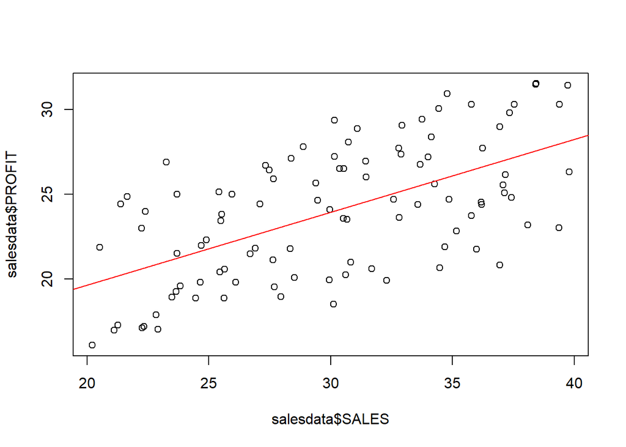

```r
sales<-lm(PROFIT~SALES,data=salesdata)
plot(salesdata$SALES,salesdata$PROFIT)
abline(sales,col="red")
```

```r
summary(sales)
```

```
##
## Call:
## lm(formula = PROFIT ~ SALES, data = salesdata)
##
## Residuals:
##     Min      1Q  Median      3Q     Max
## -6.1078 -2.6804 -0.2726  2.7188  5.8453
##
## Coefficients:
##             Estimate Std. Error t value Pr(>|t|)
## (Intercept) 11.04128    1.77822   6.209 1.29e-08 ***
## SALES        0.43040    0.05813   7.404 4.64e-11 ***
## ---
## Signif. codes:  0 '***' 0.001 '**' 0.01 '*' 0.05 '.' 0.1 ' ' 1
##
## Residual standard error: 3.128 on 98 degrees of freedom
## Multiple R-squared:  0.3587, Adjusted R-squared:  0.3522
## F-statistic: 54.82 on 1 and 98 DF,  p-value: 4.637e-11
```

#### There are high variability in the predictions by only looking at the SALES data.

#### So we should use dummy variables in predictions to increase the R squared value.

```r
len<-length(salesdata[,1])
newsales<-data.frame(PROFIT=salesdata$PROFIT,SALES=salesdata$SALES,TIME=1:len)
newsales[1:4,]
```

```
##     PROFIT    SALES TIME
## 1 18.51422 30.12393    1
## 2 20.83479 36.94505    2
## 3 16.09410 20.20793    3
## 4 20.64832 34.47554    4
```

```r
regsales<-lm(PROFIT~SALES+TIME,data=newsales)
summary(regsales)
```

```
##
## Call:
## lm(formula = PROFIT ~ SALES + TIME, data = newsales)
##
## Residuals:
##      Min       1Q   Median       3Q      Max
## -0.44876 -0.17948 -0.04109  0.14313  0.63518
##
## Coefficients:
##              Estimate Std. Error t value Pr(>|t|)
## (Intercept) 9.6060923  0.1360058   70.63   <2e-16 ***
## SALES       0.2936245  0.0045556   64.45   <2e-16 ***
## TIME        0.1099769  0.0008493  129.49   <2e-16 ***
## ---
## Signif. codes:  0 '***' 0.001 '**' 0.01 '*' 0.05 '.' 0.1 ' ' 1
##
## Residual standard error: 0.2385 on 97 degrees of freedom
## Multiple R-squared:  0.9963, Adjusted R-squared:  0.9962
## F-statistic: 1.31e+04 on 2 and 97 DF,  p-value: < 2.2e-16
```

```r
Sales_coeff<-9.6060923+0.2936245*salesdata$SALES+0.1099769+newsales$TIME
```

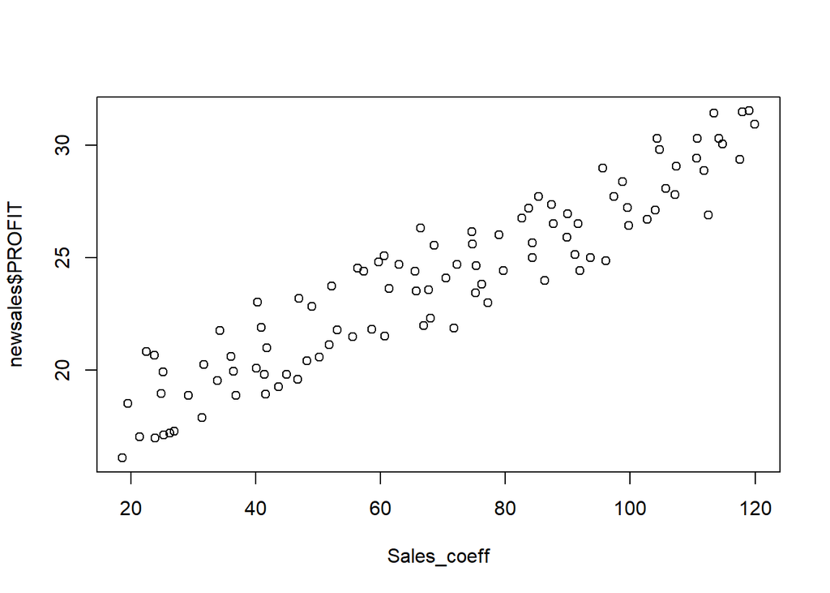

```r
plot(Sales_coeff,newsales$PROFIT)
```

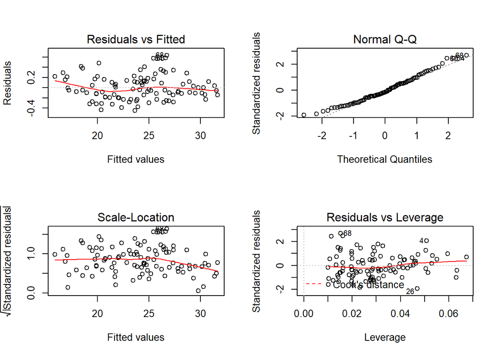

```r
par(mfrow=c(2,2))
plot(regsales)
```

```r
summary(regsales)
```

```
##
## Call:
## lm(formula = PROFIT ~ SALES + TIME, data = newsales)
##
## Residuals:
##      Min       1Q   Median       3Q      Max
## -0.44876 -0.17948 -0.04109  0.14313  0.63518
##
## Coefficients:
##              Estimate Std. Error t value Pr(>|t|)
## (Intercept) 9.6060923  0.1360058   70.63   <2e-16 ***
## SALES       0.2936245  0.0045556   64.45   <2e-16 ***
## TIME        0.1099769  0.0008493  129.49   <2e-16 ***
## ---
## Signif. codes:  0 '***' 0.001 '**' 0.01 '*' 0.05 '.' 0.1 ' ' 1
##
## Residual standard error: 0.2385 on 97 degrees of freedom
## Multiple R-squared:  0.9963, Adjusted R-squared:  0.9962
## F-statistic: 1.31e+04 on 2 and 97 DF,  p-value: < 2.2e-16
```

```r
gvlma(regsales)
```

```
##
## Call:
## lm(formula = PROFIT ~ SALES + TIME, data = newsales)
##
## Coefficients:
## (Intercept)        SALES         TIME
##      9.6061       0.2936       0.1100
##
##
## ASSESSMENT OF THE LINEAR MODEL ASSUMPTIONS
## USING THE GLOBAL TEST ON 4 DEGREES-OF-FREEDOM:
## Level of Significance =  0.05
##
## Call:
##  gvlma(x = regsales)
##
##                     Value p-value                Decision
## Global Stat        5.4956 0.24012 Assumptions acceptable.
## Skewness           3.7924 0.05149 Assumptions acceptable.
## Kurtosis           0.1614 0.68785 Assumptions acceptable.
## Link Function      0.3692 0.54344 Assumptions acceptable.
## Heteroscedasticity 1.1725 0.27888 Assumptions acceptable.
```

#### All model assumptions are fulfilled.We can see this by using gvlma function with level of significance 0.05.

```r
predict(regsales,data.frame(SALES=30,TIME=101),interval = "prediction")
```

```
##        fit      lwr      upr
## 1 29.52249 29.03921 30.00577
```

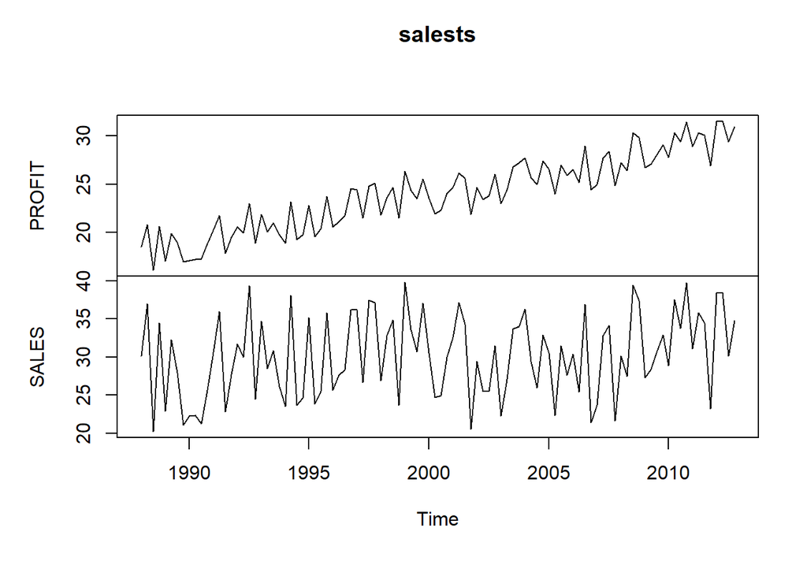

```r
salests<-ts(salesdata,freq=4,start=1988)
plot(salests)
```

```r
salests
```

```
##           PROFIT    SALES
## 1988 Q1 18.51422 30.12393
## 1988 Q2 20.83479 36.94505
## 1988 Q3 16.09410 20.20793
## 1988 Q4 20.64832 34.47554
## 1989 Q1 17.03614 22.91242
## 1989 Q2 19.92236 32.29668
## 1989 Q3 18.96735 27.95093
## 1989 Q4 16.97224 21.09954
## 1990 Q1 17.12417 22.24912
## 1990 Q2 17.21006 22.32605
## 1990 Q3 17.27179 21.26627
## 1990 Q4 18.86660 25.62476
## 1991 Q1 20.24539 30.61765
## 1991 Q2 21.75580 35.99417
```

[output cut: 86 more lines]

#### We can add the model the seosanality effect with quarters.

```r
len<-length(salesdata[,1])

x1<-1:len%%4 ==1
x2<-1:len%%4 ==2
x3<-1:len%%4 ==3
x4<-1:len%%4 ==0
powerdata<-data.frame(PROFIT=salesdata$PROFIT,SALES=salesdata$SALES,TIME=1:len,S1=x1*1,S2=x2*1,S3=x3*1,S4=x4*1)
powerdata[1:4,]
```

```
##     PROFIT    SALES TIME S1 S2 S3 S4
## 1 18.51422 30.12393    1  1  0  0  0
## 2 20.83479 36.94505    2  0  1  0  0
## 3 16.09410 20.20793    3  0  0  1  0
## 4 20.64832 34.47554    4  0  0  0  1
```

```r
fit<-lm(PROFIT~SALES+TIME+S1+S2+S3+S4,data=powerdata)
summary(fit)
```

```
##
## Call:
## lm(formula = PROFIT ~ SALES + TIME + S1 + S2 + S3 + S4, data = powerdata)
##
## Residuals:
##      Min       1Q   Median       3Q      Max
## -0.39727 -0.14822 -0.02437  0.17304  0.47302
##
## Coefficients: (1 not defined because of singularities)
##               Estimate Std. Error t value Pr(>|t|)
## (Intercept)  9.7420639  0.1256262  77.548  < 2e-16 ***
## SALES        0.2947736  0.0040791  72.264  < 2e-16 ***
## TIME         0.1098060  0.0007599 144.507  < 2e-16 ***
## S1          -0.2114063  0.0603577  -3.503 0.000707 ***
## S2          -0.3050027  0.0604004  -5.050 2.16e-06 ***
## S3          -0.1313686  0.0603554  -2.177 0.032017 *
## S4                  NA         NA      NA       NA
## ---
## Signif. codes:  0 '***' 0.001 '**' 0.01 '*' 0.05 '.' 0.1 ' ' 1
##
## Residual standard error: 0.2131 on 94 degrees of freedom
## Multiple R-squared:  0.9971, Adjusted R-squared:  0.997
## F-statistic:  6567 on 5 and 94 DF,  p-value: < 2.2e-16
```

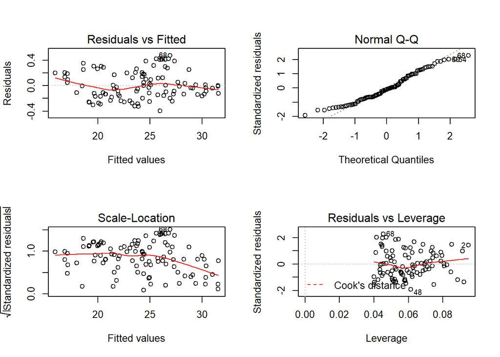

```r
par(mfrow=c(2,2))
plot(fit)
```

```r
predict(fit,data.frame(SALES=30,TIME=101,S1=1,S2=0,S3=0,S4=0),interval = "prediction")
```

```
##        fit      lwr      upr
## 1 29.46427 29.02564 29.90291
```